# SHM 377: Hazardous Materials Management

Lecture 00: Welcome to SHM 377

Author

Yoni Rodriguez

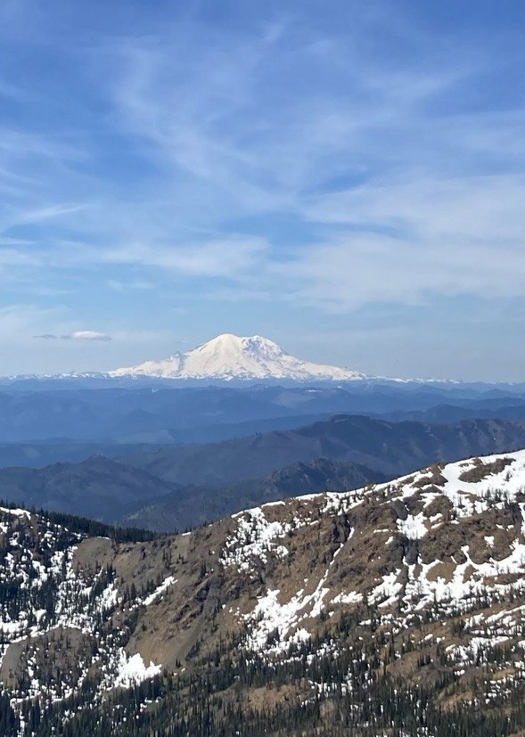

Mount Rainier, Washington. Photograph by Yoni Rodriguez, 2022.

## SHM 377: Hazardous Materials Management

### Welcome to SHM 377

**Lecture 00 · Fall 2026**

Yoni Rodriguez  
Engineering Technologies, Safety, and Construction  
Central Washington University  
Yoni.Rodriguez@cwu.edu

# Welcome

Welcome to **SHM 377: Hazardous Materials Management**.

Before we begin working with hazardous materials, regulations, environmental data, or laboratory problems, I want us to learn a little about each other and talk about how this course will work.

Today we will talk about:

- Who am I?
- Who are you?
- What is SHM 377?
- How does this course work?
- What can you expect from me?
- What do I expect from you?
- How can you succeed in this course?
- How do you communicate with professors?
- What resources are available to you at CWU?

# Who am I?

[figure not shown]

Yoni Rodriguez receiving the 2024 Peer Award at NASA Armstrong Flight Research Center, Edwards, California. Photo: [NASA Armstrong Flight Research Center](https://www.nasa.gov/armstrong/).

## Before CWU

**Environmental Health Scientist**  
NASA Armstrong Flight Research Center

## Education

**B.S. Biochemistry & Molecular Biosciences**  
Washington State University

**M.S. Exposure Science**  
University of Washington

## Today

**Assistant Professor**  
Central Washington University

**Research Scientist**  
University of Washington

# My Path Here

My path into safety, health, and hazardous materials management was not completely linear.

I began in **biochemistry and molecular biosciences**, where I became interested in how biological and chemical processes affect human health.

At the University of Washington, that interest expanded into **exposure science**: understanding what people are exposed to, how exposure occurs, how we measure it, and what it may mean for health.

My work has included occupational and environmental health research involving:

- anencephaly + water quality
- wildfire smoke | respiratory health
- heavy metals | lead exposure
- heat stress
- environmental exposure monitoring

At NASA Armstrong Flight Research Center, I worked in Code 260 (Medical) as an environmental public health scientist. I supported missions involving chemical, radiation, and biological exposures.

Today, I teach here at CWU while continuing research with the University of Washington.

**NoteWhy am I telling you this?**

There is not one path into hazardous materials management.

People enter this work through safety, chemistry, engineering, environmental science, public health, emergency response, occupational health, transportation, waste management, and many other disciplines.

During this course, you may discover connections to interests you already have.

# Tell Me About You

Before we get started, I’d like to learn a little about who’s in the room.

A few things I would like to know:

1. **What is your year at CWU?**
2. **What brought you into the Safety and Health Management program?**
3. **Have you worked with hazardous materials before?**
4. **What chemistry courses have you taken?**
5. **Have you used R, Excel, or another data-analysis tool before?**
6. **What are you hoping to get out of SHM 377?**
7. **When you hear “hazardous materials management,” what comes to mind?**

# What Is This Course?

SHM 377 examines the **management of hazardous materials in workplace settings**.

We will consider hazardous materials across their lifecycle, including:

- transportation
- receiving
- storage
- use and handling
- exposure
- releases
- emergency response
- waste management
- disposal

But the goal is not simply to memorize a list of rules for each stage.

# What Does “Management” Mean?

Imagine that you are told:

> “We are bringing a new hazardous material into the facility.”

What would you need to know?

- What is the material?
- What are its properties?
- How will it be used and stored?
- How could workers be exposed?
- What happens if it is released?
- What regulations apply?
- How will the waste be managed?

Hazardous materials management means learning how to **find and use the information needed to make a defensible decision**.

# A Framework for Hazardous Materials Management

Throughout the quarter, we will repeatedly ask:

- What is the problem?
- What information do I need?
- Where can I find that information?
- What does the evidence tell me?
- What requirements apply?
- What should we do?
- How can I defend and communicate that decision?

You are not expected to memorize every chemical property, exposure limit, regulation, or technical requirement.

The goal is to learn **what information you need, where to find it, and how to use it**.

# How SHM 377 Works

SHM 377 meets:

### Monday & Wednesday

### 1:00–3:20 PM

These extended meetings allow us to integrate **lecture and laboratory work**.

Where appropriate:

## Monday

### Concepts / Case Framing / Preparation

### ↓

## Wednesday

### Laboratory / Data / Application / Decision Making

# Lecture + Laboratory

Class meetings may include:

- interactive lectures
- hazardous materials cases
- calculations
- Safety Data Sheets
- regulatory research
- environmental and exposure data
- R and Excel
- scientific literature
- technical resources
- individual activities
- group problem solving
- laboratory work
- and project development

Not every Wednesday will produce a graded laboratory report.

Sometimes the goal is simply to **practice using the tools we will need later**.

# Chemistry in SHM 377

Chemistry is a prerequisite for this course.

But SHM 377 is **not another general chemistry course**.

We will revisit chemistry when it helps us understand or solve a hazardous materials problem.

Examples may include:

- density
- specific gravity
- mass and volume
- concentration
- parts per million
- molarity
- volatility
- solubility
- vapor pressure
- compatibility
- and reactivity

The question is not only:

> “Can you perform the calculation?”

It is also:

> **“What does the result mean for this hazardous materials problem?”**

# Regulations in SHM 377

We will work with regulations throughout the course.

You are **not expected to memorize the CFR**.

Instead, you will practice determining:

- who has authority
- what requirements apply
- where to find them
- what they require
- whether a scenario complies
- what action is needed

The goal is to learn how to **find, interpret, and apply regulations to real problems**.

# Your Professional Toolbox

Throughout the quarter, we will use different sources of information, including:

- Safety Data Sheets
- regulatory resources
- scientific and technical literature
- environmental and exposure data
- CWU Libraries and SciFinder
- analytical tools such as R and Excel
- AI tools

Different problems require different tools.

Part of SHM 377 is learning **what information you need and where to find it**.

# R and RStudio

We are going to begin the course by working with **R and RStudio**.

You do **not** need previous programming experience.

And:

## SHM 377 is not an R programming course.

R is one professional tool we can use to work with environmental and hazardous materials data.

# Why Are We Learning R?

Data are one form of evidence.

R gives us a reproducible environment for:

- importing data
- inspecting data
- organizing data
- summarizing measurements
- visualizing results
- interpreting patterns
- and documenting what we did

You are learning how to use a tool to investigate a problem.

# After Lab 01

After the introductory R laboratory, you may generally use:

- **R**
- **Excel**
- or another appropriate analytical interface

for later laboratory work unless a particular assignment requires a specific method.

Regardless of the software you choose, you remain responsible for:

- performing the analysis correctly
- documenting your work
- interpreting the results
- and explaining what the evidence means

## Support the mechanics. Assess the reasoning.

# Where Should I Look?

## Canvas

Use Canvas for:

- announcements
- assignments
- deadlines
- grades
- submissions
- copyrighted readings
- and course-specific instructions

## Course Repository

Instructor-created public materials may also be available through the [SHM 377 Hazardous Materials Management GitHub repository](https://github.com/yoni-rodriguez/shm-377-hazardous-materials-management.git).

The repository may include:

- lectures
- laboratories
- datasets
- analytical code
- templates
- assignment instructions
- and other publicly available materials

The goal is for you to be able to return to these materials later in the SHM program and throughout your professional career.

# Major Assessments

| Assessment | Points | Percent |
| --- | --- | --- |
| Graded Lab 01 | 25 | 12.5% |
| Graded Lab 02 | 25 | 12.5% |
| Graded Lab 03 | 25 | 12.5% |
| Graded Lab 04 | 25 | 12.5% |
| **Laboratory Total** | **100** | **50%** |
| Final Group Project | 100 | 50% |
| **Total** | **200** | **100%** |

# The Labs Build Toward Independence

As the quarter progresses, you will take on more responsibility for the analysis and decision-making process.

| Assessment | Level of Guidance |
| --- | --- |
| Lab 01 | Highly guided / completion based |
| Lab 02 | Guided |
| Lab 03 | Semi-structured |
| Lab 04 | Increasing independence |
| Final Group Project | Independent team integration |

The goal is to gradually move from **following a process** to **deciding what process is needed**.

# Graded Lab 01

Our first graded laboratory is:

## Virtual Lab 01

### Introduction to R & Environmental Data

Lab 01 is intentionally **highly guided and completion based**.

The goal is to establish a common analytical workflow.

It is **not** designed to determine who already knows how to program.

# What Will You Do in Lab 01?

You will practice:

- organizing project files
- creating and saving an R script
- importing environmental monitoring data
- inspecting a dataset
- performing basic transformations
- calculating descriptive statistics
- creating a visualization
- interpreting results
- and preserving a reproducible record of your work

Lab 01 will remain available as a reference throughout the quarter.

# The Final Group Project

The Final Group Project is worth **100 points**, or **50% of the course grade**.

Your group will receive a hazardous materials management scenario.

Depending on the scenario, you may need to consider:

- material characterization
- receiving
- storage
- use and handling
- exposure and release potential
- controls
- emergency considerations
- waste management
- transportation
- disposal
- regulations
- and professional communication

# The Question Changes

Early in the quarter, I may tell you:

> “Import this dataset.”

> “Calculate this value.”

> “Look at this regulation.”

As the quarter progresses, the question increasingly becomes:

> **What information do you think you need?**

That transition is intentional.

# Learning How to Learn

College requires more than simply spending time studying.

**How you study matters.**

This quarter, I want you to experiment with how you learn.

That is one reason the course includes an optional study-skills extra credit opportunity.

# Extra Credit: Learn About Learning

You may read an approved chapter from one of two books and try applying what you learn to your own coursework.

[figure not shown]

### *How to Become a Straight-A Student*

**Cal Newport**

Practical strategies for managing college work and studying effectively.

#### Plan your work

Instead of:

> “I’ll work on SHM 377 sometime tonight.”

Try:

> “From 4:00–4:45 PM, I will work through today’s hazardous materials problem.”

Give your work a specific time and place.

#### Work deeply

Create periods of focused work where you can give a difficult task your full attention.

Reduce distractions, protect the time you set aside, and focus on **one demanding task at a time**.

Forty-five focused minutes can be very different from forty-five minutes spent repeatedly switching between studying, messages, social media, and other tasks.

#### Take useful notes

Do not try to write down every word.

Listen for:

- important ideas
- explanations
- examples
- relationships between concepts
- and questions you still have

Your notes should help you **think about the material later**, not simply reproduce everything that was said.

[figure not shown]

### *Make It Stick*

**Peter C. Brown, Henry L. Roediger III, and Mark A. McDaniel**

Strategies based on research into learning and memory.

#### Practice retrieval

Instead of only putting information **into** your brain, practice pulling information **out**.

After class:

1. Close your notes.
2. Write down what you remember.
3. Reopen your notes and compare.

Ask yourself:

- What did I remember?
- What did I forget?
- What did I misunderstand?

#### Don’t confuse familiarity with learning

Rereading something can make it look familiar.

That does not necessarily mean you can explain or use it.

Close your notes and ask:

> **What can I explain without looking?**

#### Space your practice

Return to important ideas over time rather than trying to learn everything in one long study session.

For example:

**Learn → Wait → Retrieve → Check → Return later**

#### Mix what you practice

As you learn more concepts, practice deciding **which idea or tool applies to a problem** rather than studying every concept completely in isolation.

That ability to recognize and apply the appropriate concept is part of learning.

# Try It Yourself

For the extra credit reflection:

1. Read an approved chapter from either book
2. Identify an idea that seems useful to you
3. Connect it to how you currently approach learning
4. **Try the strategy**
5. Reflect on what happened

You do not have to decide that the strategy worked.

The goal is to experiment with your own learning and think about the results.

**Maximum: 5 extra credit points**

# Communicating With Professors

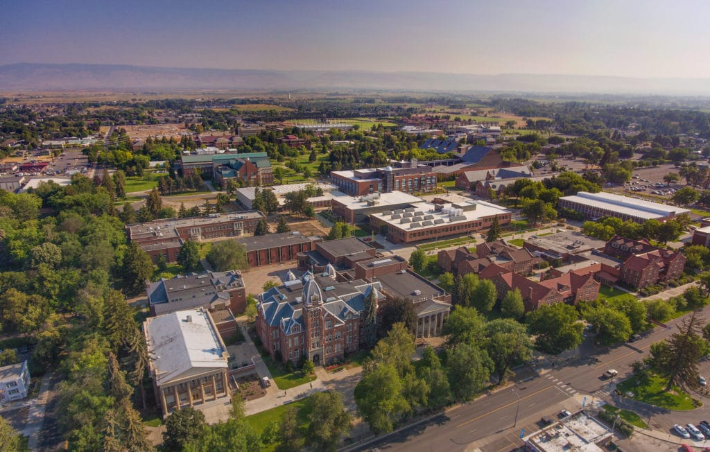

Central Washington University campus. Photo: [Central Washington University](https://www.cwu.edu/).

College may be the first time you regularly communicate with professors outside of a classroom.

There are some simple professional habits that can make those interactions easier.

## Faculty Are Different

Faculty have different:

- personalities
- expectations
- communication styles
- schedules
- research interests
- approaches to teaching
- preferences for how students communicate with them

You do not need a special script to speak with a professor.

Start with the same principles you would use in a professional workplace:

### Be respectful. Be clear. Provide context. Ask for what you need.

## Approaching a Professor’s Office

If you visit a professor’s office:

- **Knock before entering**, even if the door is open
- Wait for the professor to invite you in
- Introduce yourself if the professor may not know you yet
- Ask whether it is a good time to talk
- Do not assume an open office door means you should enter and sit down
- If the professor is meeting with someone else, give them privacy and come back later

You can simply say:

> “Hi Professor Rodriguez, do you have a few minutes?”

If it is not a good time, ask when you should come back or whether you should schedule an appointment.

**NoteWhat about office hours?**

**Office hours are specifically reserved for students.**

You are welcome to come during my scheduled drop-in office hours without making an appointment first.

Mondays and Wednesdays 10:00 am - 11:30 am

# Before You Email

Ask yourself:

1. **What am I asking?**
2. **What information does the professor need to answer me?**
3. **Would this be easier to discuss in person?**

Email works well for:

- quick questions
- clarification
- absence notifications
- scheduling
- simple requests

Complex questions about a laboratory, your performance in the course, a grade, the Final Project, or personal circumstances may be easier to discuss during office hours or an appointment.

# A Useful Email Structure

You do not need to write a long or overly formal email.

Give the professor enough information to understand **who you are and what you need**.

### Subject

**SHM 377 Question About [Topic or Assignment]**

### Greeting

Hello Professor Rodriguez,

### Context

I’m in your SHM 377 course.

### Question

I’m working on [assignment/topic], and I have a question about…

### What you’ve already tried

I reviewed [lecture/Canvas/instructions/resource], but I’m still unsure about…

### Close

Thank you,  
[Your Name]

# Example Email

> **Subject:** SHM 377 Question About Lab 02

> Hello Professor Rodriguez,

> I’m working on Lab 02 and had a question about exposure limits. I was able to calculate the concentration, but I’m not sure which exposure limit is appropriate for the scenario.

> I reviewed the lab instructions and lecture notes, but I’m still unsure how to decide which limit applies.

> Could you point me toward the resource I should use?

> Thank you,  
> [your name]

# Asking About a Grade

It is completely appropriate to ask questions about your grade or feedback.

For example:

> “Could you help me understand where I lost points?”

or

> “I reviewed the feedback and had a question about this section.”

or

> “What should I improve before the next laboratory?”

Those questions give us something useful to discuss.

If you think something may have been graded incorrectly, you can ask about that too.

The goal is to understand **how your work was evaluated and what you can do next**.

# Office Hours

Office hours are time specifically reserved for students.

For SHM 377:

### Monday & Wednesday

### 10:00–11:30 AM

### Drop in

You do **not** need an appointment during scheduled drop-in hours.

# You Don’t Need to Have a Problem

Come to office hours to:

- ask about something from class
- review chemistry
- troubleshoot R or Excel
- work through a calculation
- navigate a regulation
- discuss your Final Project
- ask about careers
- talk about internships
- discuss research
- get feedback
- or simply introduce yourself

# “I Don’t Know What to Ask”

That’s okay.

You can approach and say:

> “I’m having trouble understanding vapor pressure.”

or

> “I don’t know where to start on this regulation.”

or

> “My R code isn’t working and I don’t understand the error.”

or even:

> “I understand the lecture when you’re explaining it, but when I try the problem by myself I get lost.”

That gives us somewhere to start.

# Bring the Problem With You

When asking for help with a technical problem, bring what you have.

That might include:

- the assignment
- your notes
- your calculation
- your R script
- your Excel file
- the error message
- the regulation
- the SDS
- or the resource you were using

You do not need to solve the problem before asking for help.

Showing what you tried helps us identify **where the problem started**.

# Use Your Resources

You have access to more than this classroom.

CWU provides resources to support you throughout your time at the university.

- **Academic support:** [Learning Commons](https://www.cwu.edu/academics/academic-resources/learning-commons/tutoring/index.php)
- **Research and library assistance:** [CWU Libraries](https://www.lib.cwu.edu/)
- **Academic advising:** [Academic Advising](https://www.cwu.edu/academics/academic-resources/academic-advising/index.php)
- **Accessibility and accommodations:** [Disability Services](https://www.cwu.edu/student-life/student-support/disability-services/index.php)
- **Counseling and wellbeing:** [Student Counseling Services](https://www.cwu.edu/student-life/health-wellness-services/counseling-services/index.php)
- **Career development:** [Career Services](https://careerservices.cwu.edu/)
- **Technology:** [Technology Resources](https://www.cwu.edu/academics/colleges/college-business/student-resources/technology-resources.php)

Part of succeeding in college is learning **where to go when you need something**.

# CWU Libraries

On **Monday, September 28**, we will meet at the:

### CWU Library

### 1:00–2:00 PM

We will explore:

- CWU Libraries resources
- OneSearch
- finding physical and digital materials
- and **SciFinder** for locating scientific information about hazardous chemicals

These resources will support our laboratory work and Final Group Project throughout the quarter.

# When Life Happens

Illness happens.

Emergencies happen.

Transportation problems happen.

Family situations happen.

Unexpected things happen.

The important professional habit is:

## Communicate.

You do not need to provide unnecessary personal details.

Tell me what I need to know so that we can determine the appropriate next step.

## Example Message

> **Subject:** SHM 377 Absence

> Hello Professor Rodriguez,

> I won’t be able to attend SHM 377 today because of an unexpected personal situation. I will check Canvas and review the course materials I missed.

> Please let me know if there is an in-class laboratory activity or anything else I should follow up on.

> Thank you,  
> [your name]

Notice what the message does:

- explains that the student will be absent
- communicates as early as possible
- shows that they will check the available course materials
- asks what they need to do next
- and does **not** require them to share private details

The goal is not to explain everything that happened.

The goal is to **communicate what is affecting the course and determine the next step**.

# Artificial Intelligence

Artificial intelligence is **not prohibited** in SHM 377.

You may use AI thoughtfully for:

- learning
- problem solving
- coding assistance
- brainstorming
- troubleshooting
- and improving your understanding

But AI should support rather than replace your own thinking.

# You Are Responsible for the Work

If AI materially contributes to submitted work:

- identify the tool
- briefly explain how you used it
- verify factual claims
- verify calculations
- verify regulatory information
- verify code
- verify sources
- and understand what you submit

Do not assume generated information is correct.

## You should be able to explain your work.

# Verification Is a Professional Habit

If an AI system tells you:

> “According to 29 CFR…”

your next step should be to **open the regulation and verify it**.

The same principle applies to information from:

- websites
- search engines
- coworkers
- technical documents
- AI
- and other secondary sources

Ask:

## Where did this information come from?

## Can I verify it?

# Professional Habits Start Now

Your professional reputation does not suddenly begin after graduation.

Practice now:

- showing up and participating
- communicating
- meeting commitments
- asking questions
- listening
- accepting feedback
- checking your work
- admitting when you don’t know something
- finding credible information
- documenting what you did
- explaining your reasoning
- and treating people respectfully

These habits transfer far beyond SHM 377.

# Clear > Complicated

Professional communication does not mean using the biggest words possible.

Your goal is to communicate technical information:

**accurately**

and

**in a way your audience can understand.**

Hazardous materials professionals may need to communicate with:

- workers
- employers
- scientists
- engineers
- emergency responders
- regulators
- managers
- and communities

Being technically correct matters.

Being understood matters too.

# What I Want You to Leave With

By the end of SHM 377, I do not expect you to have memorized every chemical property, regulation, equation, or exposure limit.

I want you to be able to encounter a hazardous materials problem you have **never seen before** and determine:

- what you need to know
- where to find reliable information
- what the evidence tells you
- what action is needed
- how to defend your decision

That is the skill we are going to practice.

# Important Dates

### September 28

**CWU Libraries Session**  
Meet at the CWU Library from 1:00–2:00 PM.

### September 29

**Last day of the regular CWU Change of Schedule Period**

### September 30

**Lecture 01: Introduction to SHM 377**

# Questions?

### Welcome to SHM 377.

Let’s have a good quarter.

© 2026 Yoni Rodriguez. SHM 377: Hazardous Materials Management. Except where otherwise noted, instructor-created course materials are licensed under CC BY-NC 4.0.